# Estudo prova 2

Miguel Sallum

13/06/2021

## Regression Discontinuity Design

A ideia é que você tem uma variação descontínua na *running variable*(X), como a chance de entrar num curso dado sua nota, ou o número de recursos recebidos por uma cidade dado o tamanho da população. A partir disso, é possível estimar o efeito local da variavel intermediária (a que tem essa mudança de regra de acordo com X) sobre o resultado de interesse. Essa medida é chamada de **Local Average Treatement Effect**, o LATE, e, em notação de PO, é definida como:
$$LATE\ =\ E[Y^1|X\rightarrow x_0^+]\ -\ E[Y^0|X\rightarrow x_0^-]$$
Vamos então construir dados e estimar tal modelo

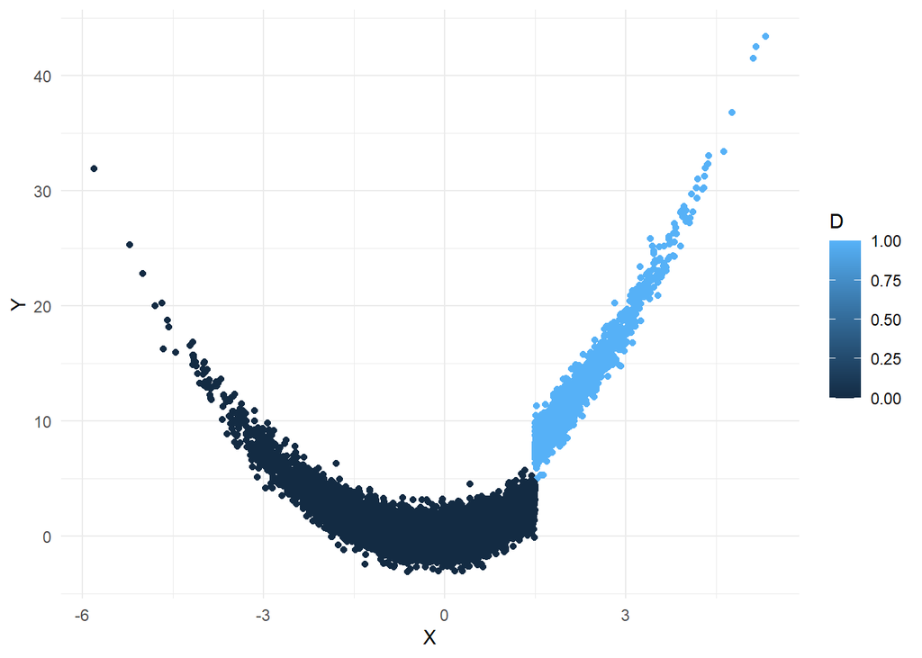

```r
n = 10000
RDDados <- tibble(
  U = rnorm(n),
  X = rnorm(n) + U,
  D = as.numeric(X > 1.5),
  Y = 2*D + 0.5*X + X^2 +2*X*D +rnorm(n))

RDDados%>%
  ggplot(aes(x = X, y = Y, colour = D)) +
  geom_point() +
  theme_minimal()
```

É muito claro no gráfico que a descontinuidade existe. Agora, estimemos a regressão.

```r
RDDados %>%
  lm(Y ~ D*poly(X, degree = 2), .) %>%
  summary()
```

```
##
## Call:
## lm(formula = Y ~ D * poly(X, degree = 2), data = .)
##
## Residuals:
##     Min      1Q  Median      3Q     Max
## -3.5463 -0.6815 -0.0075  0.6771  4.1635
##
## Coefficients:
##                         Estimate Std. Error t value Pr(>|t|)
## (Intercept)              1.95848    0.01346 145.489  < 2e-16 ***
## D                        1.87591    0.40570   4.624 3.81e-06 ***
## poly(X, degree = 2)1    65.28445    1.84543  35.376  < 2e-16 ***
## poly(X, degree = 2)2   275.42876    1.83708 149.928  < 2e-16 ***
## D:poly(X, degree = 2)1 297.26747   35.97045   8.264  < 2e-16 ***
## D:poly(X, degree = 2)2  -2.60021   13.50315  -0.193    0.847
## ---
## Signif. codes:  0 '***' 0.001 '**' 0.01 '*' 0.05 '.' 0.1 ' ' 1
##
## Residual standard error: 1.01 on 9994 degrees of freedom
## Multiple R-squared:  0.9571, Adjusted R-squared:  0.9571
## F-statistic: 4.459e+04 on 5 and 9994 DF,  p-value: < 2.2e-16
```

Alguma coisa está errada no X, preciso olhar com calma depois.

### Checando estimativa

A sua estimativa do efeito de D é dependende do fato da descontinuidade ser feita somente nas variaveis de interesse. A descontinuidade não pode aparecer em outras variaveis, ou até mesmo na densidade da distribuição

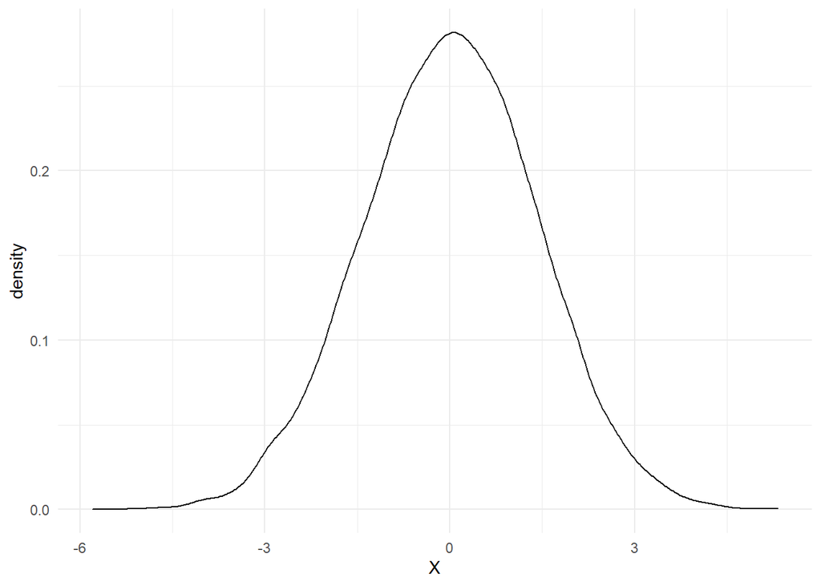

## Instrumental Variables Model

Quando há correlação entre os não observáveis entre a variável de tratamento e resultado de interesse, a nossa estimativa será viesada. Para isso, usamos uma variavel instrumental, uma variavel que afeta o tratamento E só afeta o resultado através do tratamento. Em Potencial Outcomes:
$$E[Y(D=i, Z=1)]\ =\ E[Y(D=i, Z=0)],\ i \in\{0,\ 1\}$$

Alternativamente, podemos representar com um DAG:

[interactive chart not shown]

Façamos um exemplo:

```r
IV <- tibble(
  Z = as.numeric(runif(n) > .5),
  U = runif(n),
  D = as.numeric(U + 0.25*Z > .6),
  Y = rnorm(n) + U +D)
```

(Aqui ambos o instrumento(Z) e o tratamento(D) são variáveis binárias, mas não precisam ser!)

Estimemos agora uma OLS simples e os dois estágios da variável instrumental

```r
coefs <- IV %>%
  summarise(
    OLS = coef(lm(Y ~ D))[[2]],
    first_stage = coef(lm(D ~ Z))[[2]],
    reduced_form = coef(lm(Y ~ Z))[[2]],
    Wald_estimate = reduced_form/first_stage)

coefs
```

```
## # A tibble: 1 x 4
##     OLS first_stage reduced_form Wald_estimate
##   <dbl>       <dbl>        <dbl>         <dbl>
## 1  1.48       0.243        0.247          1.02
```

Podemos ver que a estimativa pontual correta é Wald estimate, e que o OLS é viesado. No entanto ainda precisamos estimar a variância. Usaremos então a função própria de IV, do pacote AER

```r
ivreg(Y ~ D | Z, data = IV) %>%
  summary()
```

```
##
## Call:
## ivreg(formula = Y ~ D | Z, data = IV)
##
## Residuals:
##       Min        1Q    Median        3Q       Max
## -3.931253 -0.702741 -0.005403  0.707463  4.378567
##
## Coefficients:
##             Estimate Std. Error t value Pr(>|t|)
## (Intercept)  0.48118    0.04665   10.31   <2e-16 ***
## D            1.01596    0.08574   11.85   <2e-16 ***
## ---
## Signif. codes:  0 '***' 0.001 '**' 0.01 '*' 0.05 '.' 0.1 ' ' 1
##
## Residual standard error: 1.043 on 9998 degrees of freedom
## Multiple R-Squared: 0.3112,  Adjusted R-squared: 0.3111
## Wald test: 140.4 on 1 and 9998 DF,  p-value: < 2.2e-16
```